# Analysis on Game of Thrones character names and marriage survival

In this notebook, I’ll …

- … download data from the “Song of Ice and Fire API”, https://anapioficeandfire.com/. A web API is a way to download data from the internet. The asoif API is a repository that contains a lot of GOT related data.
- … make data transformations to ready data for analysis
- … examine two research questions and create appropriate visualizations and analysis on the data

```r
# Load packages
library(tidyverse)
library(magrittr)
library(httr)
library(forcats)
library(tidytext)
library(wordcloud2)
library(stringr)
library(ggridges)
```

First we have to download the data from the web. This API is “paginated”, which means that the data can be downloaded as it was a homepage with a fixed page size (e.g. 50 book characters in a page), and you have access to ‘next’ and ‘previous’ button links. So we need to build a loop to collect data from all characters.

```r
# A loop to get paginated responses from ASOIAF API
page <- 1
newpage <- httr::GET(paste0("https://www.anapioficeandfire.com/api/characters?page=", page,"&pageSize=50"), accept_json())
got_content <- newpage %>% content()
while(headers(newpage)$link %>% grepl("rel=\"next\"", .))
  # Collect data until `next` link disappear
{
  page <- page + 1
  newpage <-
    httr::GET(paste0("https://www.anapioficeandfire.com/api/characters?page=",page,"&pageSize=50"),
      accept_json()
    )
  got_content %<>% append(content(newpage))
  cat("=")
}
length(got_content)
```

```
[1] 2134
```

We collected a whooping 2134 characters from the Game of Thrones universe!

In the next block, we transform the data from the awkward hierarchical data structure into a data frame, that is easy to use. We also clean the data to get meaningful variables.

```r
# Put list data into nested data frame
got_chars_df <-
  got_content %>%
  tibble( # Create an analyzable data frame from the complex list object
    url = map_chr(., "url"),
    name = map_chr(., "name"),
    gender = map_chr(., "gender"),
    culture = map_chr(., "culture"),
    born = map_chr(., "born"),
    died = map_chr(., "died"),
    titles = map(., "titles"),
    aliases = map(., "aliases"),
    father = map_chr(., "father"),
    mother = map_chr(., "mother"),
    spouse = map_chr(., "spouse"),
    allegiances = map(., "allegiances"),
    books = map(., "books"),
    povBooks = map(., "povBooks"),
    tvSeries = map(., "tvSeries"),
    playedBy = map(., "playedBy")
  ) %>%
  mutate_if(is.character,funs(if_else(trimws(.) == "",NA_character_, .))) %>% # Explicit NA
  rowwise() %>%
  mutate(
         alias_length = length(aliases), # How many aliases does the person have
         alias_names = unlist(aliases) %>% paste(collapse = ", "), # Collapse aliases to one string
         has_spouse = if_else(!is.na(spouse), TRUE, FALSE), # Have a spouse?
         birth_year = str_extract(born, " \\d* ") %>% as.numeric(), # Extract birthyear
         death_year = str_extract(died, " \\d* ") %>% as.numeric(), # Extract deathyear
         is_alive = if_else(is.na(died) & 300 - birth_year < 100, TRUE, FALSE), # Alive?
         age = if_else(is_alive, 300 - birth_year, death_year - birth_year)) %>% # Age (or age when died)
  arrange(name)
```

```r
head(got_chars_df)
```

| . | url | name | gender | culture | born | died | titles | aliases | father | mother | spouse | allegiances | books | povBooks | tvSeries | playedBy | alias_length | alias_names | has_spouse | birth_year | death_year | is_alive | age |
| --- | --- | --- | --- | --- | --- | --- | --- | --- | --- | --- | --- | --- | --- | --- | --- | --- | --- | --- | --- | --- | --- | --- | --- |
|  | https://www.anapioficeandfire.com/api/characters/29 | Abelar Hightower | Male | NA | NA | NA |  |  | NA | NA | NA |  |  |  |  |  | 1 |  | FALSE | NA | NA | NA | NA |
|  | https://www.anapioficeandfire.com/api/characters/1138 | Addam | Male | NA | NA | NA |  |  | NA | NA | NA |  |  |  |  |  | 1 |  | FALSE | NA | NA | NA | NA |
|  | https://www.anapioficeandfire.com/api/characters/30 | Addam Frey | Male | NA | NA | NA |  |  | NA | NA | NA |  |  |  |  |  | 1 |  | FALSE | NA | NA | NA | NA |
|  | https://www.anapioficeandfire.com/api/characters/31 | Addam Marbrand | Male | NA | NA | NA |  |  | NA | NA | NA |  |  |  |  |  | 1 |  | FALSE | NA | NA | NA | NA |
|  | https://www.anapioficeandfire.com/api/characters/32 | Addam Osgrey | Male | NA | In 183 AC or 184 AC | In 196 AC, at Redgrass Field |  |  | NA | NA | NA |  |  |  |  |  | 1 |  | FALSE | 183 | 196 | FALSE | 13 |
|  | https://www.anapioficeandfire.com/api/characters/33 | Addam Velaryon | Male | Valyrian | In 114 AC, at Hull | In 130 AC, at Tumbleton |  |  | NA | NA | NA |  |  |  |  |  | 1 | Addam of Hull | FALSE | 114 | 130 | FALSE | 16 |

# Analysis question 1: What offensive aliases the GOT characters have? Who has the most offensive ones?

Game of thrones characters have many nicknames, that are often used. We are going to mine these names and check if these words have negative or positive connotation.

In order to do this, we are getting aliases and assign sentiment values for them. But first, let’s see who has the most names.

```r
# Preparing data for analysis on aliases
long_names <-
  got_chars_df %>%
    select(name, alias_length, alias_names) %>%
    unnest_tokens(word, alias_names) %>% # Create a word-wise tidy dataset
    left_join(get_sentiments("bing"), by = "word") %>% # Add a sentiment dictionary
    rowwise() %>%
    filter(!grepl(word, str_to_lower(name))) # Remove oiginal names from the alias
```

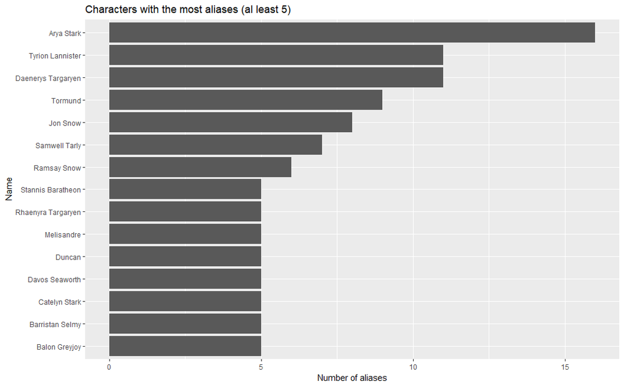

```r
# Who has the most aliases? (showing the ones (with at least 5 aliases)
long_names %>%
  filter(alias_length >= 5) %>%
  ggplot() +
    aes(y = alias_length, x = fct_reorder(name, alias_length)) +
    geom_col(position = "dodge") +
    scale_x_discrete() +
    coord_flip() +
    labs(y = "Number of aliases", x = "Name") +
    ggtitle("Characters with the most aliases (al least 5)")
```

```r
# Create a wordcloud of the aliases
long_names %>%
  anti_join(stop_words, by = "word") %>% # Remove stopwords
  group_by(word) %>%
  count() %>%
  wordcloud2()
```

[interactive chart not shown]

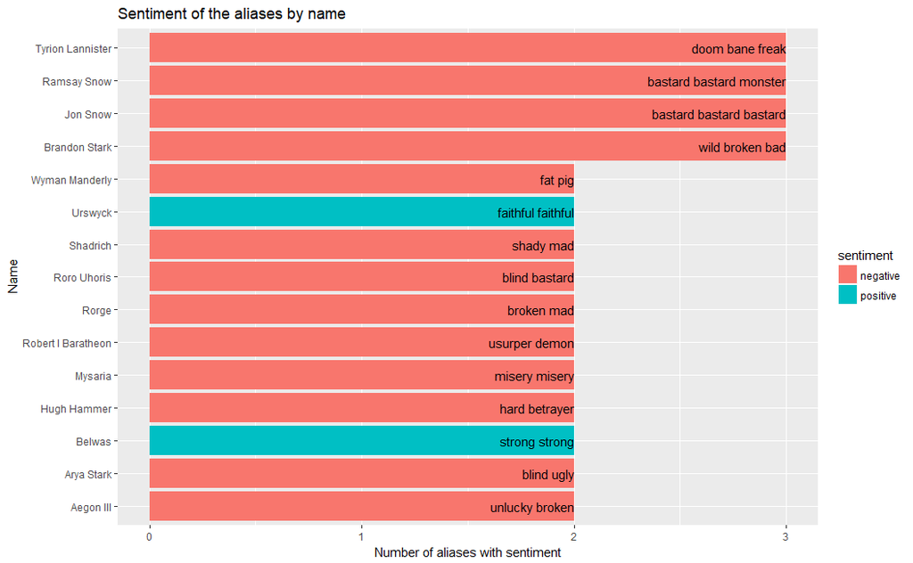

```r
# Show the character alias sentiments
long_names %>%
  anti_join(stop_words, by = "word") %>%
  drop_na(sentiment) %>%
  group_by(name, sentiment) %>%
  summarise(full_alias = paste(word, collapse = " "),
            alias_length = first(alias_length),
            sentiment_n = n()) %>%
  filter(sentiment_n>1) %>%
  arrange(-alias_length) %>%
  ggplot() +
    aes(x = fct_reorder(name, sentiment_n), y = sentiment_n, fill = sentiment, label = full_alias) +
    geom_col() +
    geom_text(hjust = 1) +
    coord_flip() +
    labs(y = "Number of aliases with sentiment", x = "Name") +
    ggtitle("Sentiment of the aliases by name")
```

So, we can conclude that the Tyrion Lennister, Ramsey Snow, Jon Snow, and Brandon Stark has the most aliases with negative connotations. Honestly I think that the standard sentiment library is not perfectly suitable for this job as it does not contain sentiments for “king slayer”, “silver tongue”, or “horse face”. So a more suitable sentiment library should be used to improve the accuracy of this analysis.

# Analysis question 2: Exploring survival chance of got characters

Based on the data of 585 characters whose death was documented in got, it seems like males have a higher higher age at death (mean = 36.5, sd = 22.7) than females (mean = 28.2 sd = 16.5). Not that high. Also, males expected age of death is based on almost 5 times as many observations.

| gender | Mean | Sd | N |
| --- | --- | --- | --- |
| Female | 28.2 | 16.5 | 102 |
| Male | 36.5 | 22.7 | 483 |

# So how dangerous is a marriage in GOT?

People die left and right in game of thrones, but no occasion is as deadly as a good wedding. But what about marriage? How people fare if they survived their wedding? In real life, lifetime expectancy is increased by marriage, which is obviously not the case in Game of Thrones. But exactly how dangerous is to be married in GOT?

We are building a logistic binomial regression on got character data with the outcome variable that shows if the character is alive or not. We restrict the analysis to characters that were born within a 102 years (This is the age of oldest character that dies in the books) because we want to focus on the book’s story-line. We are only looking for main effects of age, gender, and marital status (if the character has a spouse). Disclaimer: This is obviously a very simple minded analysis, and I only did that to show how this kind of stuff can be done in R.

```r
got_chars_df %>%
    filter(birth_year >=198) %>% # Restrict analysis to recent events in got (last 102 years)
    select(is_alive, has_spouse, gender) %>%
    ftable()
```

```
                    gender Female Male
is_alive has_spouse
FALSE    FALSE                 15   48
         TRUE                  13   27
TRUE     FALSE                 79  143
         TRUE                  32   29
```

The data is based on 386 characters, with the characteristics above. To explore data, we create a box plot visualization about age by gender by marital status by survival status.

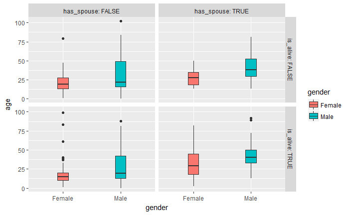

```r
got_chars_df %>%
    filter(birth_year >=198) %>% # Restrict analysis to recent events in got (last 102 years)
    ggplot() +
      aes(y = age, x = gender, fill = gender) +
      geom_boxplot() +
      facet_grid(is_alive~has_spouse, labeller = label_both)
```

```r
survival_model <-
  got_chars_df %>%
  filter(birth_year >=198) %>%
      glm(is_alive ~ age + has_spouse + gender, family = "binomial", data = .)
survival_model %>% summary
```

```
Call:
glm(formula = is_alive ~ age + has_spouse + gender, family = "binomial",
    data = .)

Deviance Residuals:
    Min       1Q   Median       3Q      Max
-2.0549  -1.1724   0.6902   0.7864   1.2898

Coefficients:
                Estimate Std. Error z value Pr(>|z|)
(Intercept)     1.990591   0.280269   7.102 1.23e-12 ***
age            -0.008283   0.005992  -1.382  0.16687
has_spouseTRUE -0.869603   0.268282  -3.241  0.00119 **
genderMale     -0.619333   0.275081  -2.251  0.02436 *
---
Signif. codes:  0 ‘***’ 0.001 ‘**’ 0.01 ‘*’ 0.05 ‘.’ 0.1 ‘ ’ 1

(Dispersion parameter for binomial family taken to be 1)

    Null deviance: 434.44  on 380  degrees of freedom
Residual deviance: 413.35  on 377  degrees of freedom
  (5 observations deleted due to missingness)
AIC: 421.35

Number of Fisher Scoring iterations: 4
```

We also calculate odds ratios, and confidence intervals for those for visualization of effects.

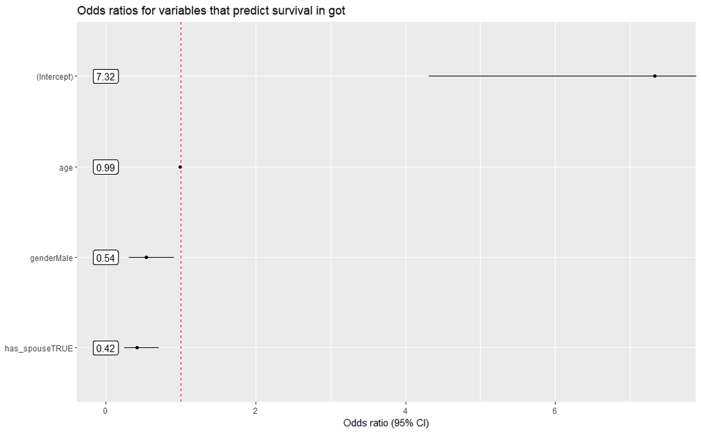

```r
survival_or <-
exp(cbind(coef(survival_model), confint(survival_model))) %>%
  round(2) %>%
  broom::tidy() %>%
  set_names(c("variable", "OR","2.5% CI","97.5% CI"))
survival_or %>%
  ggplot() +
    aes(x = OR, y = fct_rev(variable), xmin = `2.5% CI`, xmax = `97.5% CI`, label = OR) +
    geom_label(aes(x = 0)) +
    geom_errorbarh(height = 0) +
    geom_point() +
    geom_vline(aes(xintercept = 1), color = "red", linetype = "dashed") +
    coord_cartesian(c(0,7.5)) +
    labs(x = "Odds ratio (95% CI)", y = NULL) +
    ggtitle("Odds ratios for variables that predict survival in got")
```